# Chapter 6: Logistic Regression for Categorical Outcome Variables

### Likelihood Ratio Test for Comparing Nested Models

When including a categorical variable (a `Factor`-type variable) in a model, R will automatically select a reference category and represent the K categories with k-1 dummy variables (see the Chapter 3 material for further explanation).

In this example, we are adding the `marital` variable, which has 5 categories. There will be 4 dummy variables, and the reference category will be whichever category is currently specified as the first level of the `marital` factor. You can use the `levels()` function to check the levels of a variable and find out what the reference category is:

```r
levels(jobdat$marital)
```

```
[1] "nevmarr" "married" "separtd" "divrcd"  "widowed"
```

```r
#nevmarr is the reference category
```

Here, `nevmarr`, or “Never Married”, is the reference category because it is listed first. If you want to change your reference category, you can do so using the `relevel()` function in the `stats` package.

```r
#Specify reference category using the ref= argument
jobdat$marital <- relevel(jobdat$marital, ref= "nevmarr")
#Here, we're just demonstrating the function, and leaving "nevmarr" as the reference category.
```

```r
#Fitting an expanded model with the marital status dummy variables
mod2 <- glm(work ~ treat + age + marital, family=binomial, data=jobdat)
summary(mod2)
```

```
Call:
glm(formula = work ~ treat + age + marital, family = binomial,
    data = jobdat)

Coefficients:
                Estimate Std. Error z value Pr(>|z|)
(Intercept)     0.379359   0.296942   1.278   0.2014
treat           0.307053   0.156877   1.957   0.0503 .
age            -0.038930   0.008695  -4.477 7.57e-06 ***
maritalmarried  0.088342   0.188579   0.468   0.6395
maritalsepartd  0.214430   0.417628   0.513   0.6076
maritaldivrcd   0.425952   0.231376   1.841   0.0656 .
maritalwidowed -0.296789   0.672998  -0.441   0.6592
---
Signif. codes:  0 '***' 0.001 '**' 0.01 '*' 0.05 '.' 0.1 ' ' 1

(Dispersion parameter for binomial family taken to be 1)

    Null deviance: 1135.0  on 898  degrees of freedom
Residual deviance: 1103.5  on 892  degrees of freedom
AIC: 1117.5

Number of Fisher Scoring iterations: 4
```

```r
#The output contains a logistic regression slope estimate (and t-test) for each dummy variable. For example:
#"maritalmarried" compares the "married" category with "nevmarr"
#Being married doesn't significantly effect the work outcome (p = .6395), holding treat and age constant.
```

Like other effects in logistic regression, we need to exponentiate the dummy variable slope estimates for interpretation:

```r
exp(coef(mod2))
```

```
   (Intercept)          treat            age maritalmarried maritalsepartd
     1.4613476      1.3594127      0.9618178      1.0923618      1.2391557
 maritaldivrcd maritalwidowed
     1.5310474      0.7432006
```

```r
#The odds of a married person being employed is 1.09 times the odds of a never-married person being employed.

#The odds of a widowed person being employed is 74% of the odds of a never-married person being employed.
```

```r
#Likelihood ratio test comparing less complex model to more complex model
anova(mod1, mod2, test = "Chisq")
```

```
Analysis of Deviance Table

Model 1: work ~ treat + age
Model 2: work ~ treat + age + marital
  Resid. Df Resid. Dev Df Deviance Pr(>Chi)
1       896     1108.0
2       892     1103.5  4   4.4998   0.3426
```

```r
#Because Model 2 does not fit significantly better than Model 1, conclude that marital status is not significantly related to employment, holding treat and age constant.
```

### Logistic Regression Model Diagnostics

#### Figure 6.2 Assumption checks

The `residualPlots()` function from the `car` package is handy for creating diagnostic plots for logistic regression as well as basic linear models.

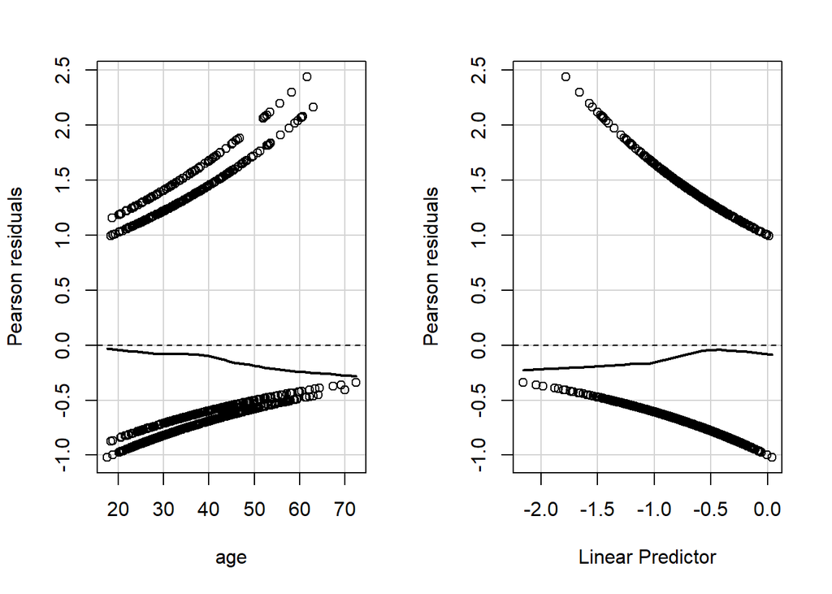

```
    Test stat Pr(>|Test stat|)
age    0.0739           0.7858
```

```r
#Plot of Pearson residuals against predicted logists of age using the car package.

#Here we include all of the terms of the model except for "treat," because it is binary
#We have also specified that a loess line should be included in the plot

residualPlots(mod1, terms = ~. -treat, smooth=list(smoother=loessLine, span=2/3, col=carPalette()[1]))
```

The `influenceIndexPlot()` function from the `car` package can create an index plot of the Cook’s distance values.

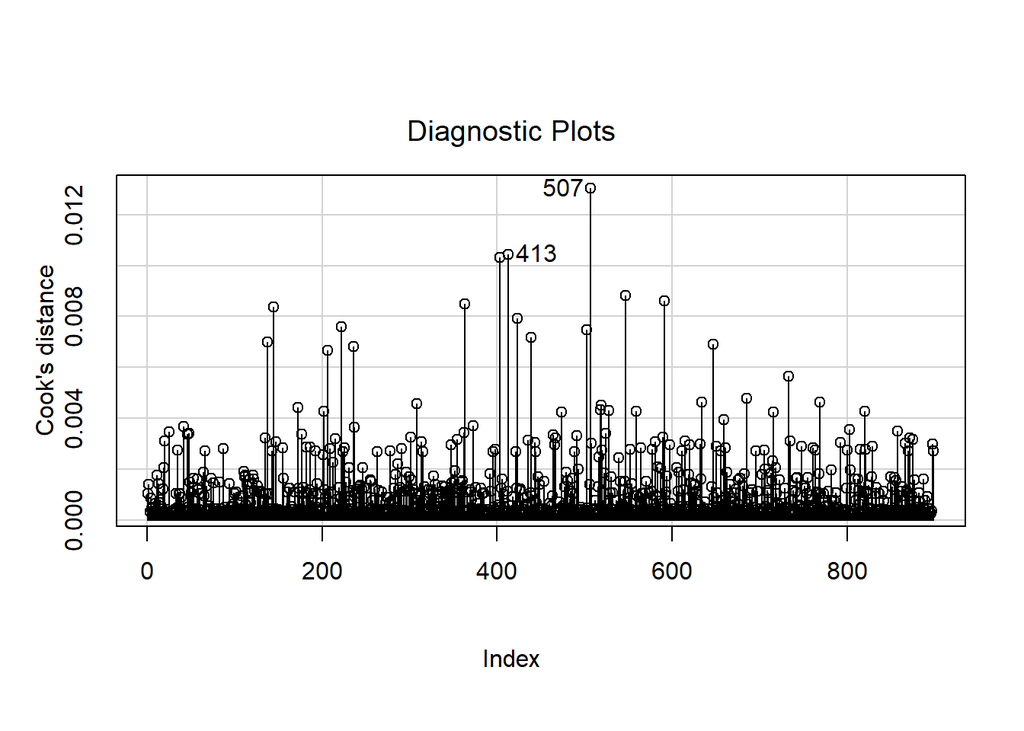

```r
#Cook's distance Index plot.
influenceIndexPlot(mod1, vars="Cook")
```

## Logistic Regression for Outcomes with More than Two Categories

### Research Example

For this research example, we are using data from the World Values Survey of 1995-1997, included in the `carData` package.

#### Importing Data

```r
library(carData)
data(WVS)
summary(WVS)
```

```
        poverty     religion   degree          country          age
 Too Little :2708   no : 786   no :4238   Australia:1874   Min.   :18.00
 About Right:1862   yes:4595   yes:1143   Norway   :1127   1st Qu.:31.00
 Too Much   : 811                         Sweden   :1003   Median :43.00
                                          USA      :1377   Mean   :45.04
                                                           3rd Qu.:58.00
                                                           Max.   :92.00
    gender
 female:2725
 male  :2656
```

For this example, we won’t use the gender variable, so we can remove it as we save the data frame into a new object:

```r
#Removing the 6th column and creating wvsdat data frame
wvsdat <- WVS[,-6]
```

```r
#Renaming the poverty variable and specifying that it is a factor (i.e., categorical).
wvsdat$attitude <- as.factor(wvsdat$poverty)
```

### Graphs of variable distributions

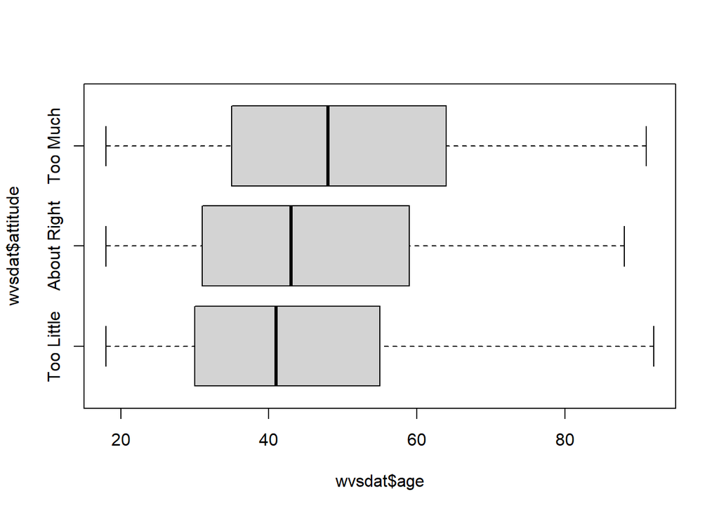

```r
#Boxplot of distribution of age by attitude
boxplot(wvsdat$age ~ wvsdat$attitude, horizontal = T)
```

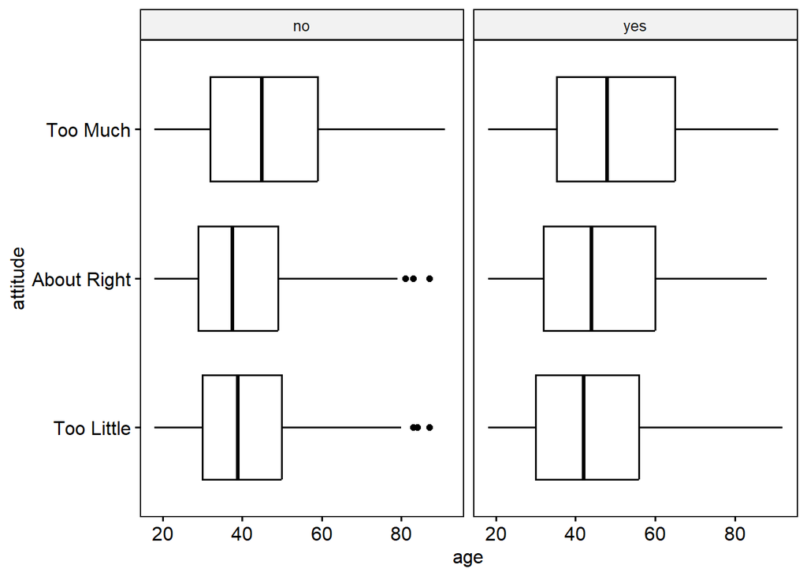

```r
#Boxplot of distribution of age by attitude and religion.

#The "facet.by" argument is used to specify the variable used for creating individual plots.
ggboxplot(wvsdat, y="age", x="attitude", facet.by = "religion", orientation="horizontal",
          palette = c("#00AFBB", "#E7B800"))
```